# Generate Puma to County Crosswalk

Author

JP Walsh

Published

June 24, 2026

*Program for the creation of the PUMA to County crosswalk for UMF predictors*

## Executive Summary

This document generates PUMA-to-County crosswalk files for the UMF mobility metrics project. **NEW**: This version includes 2000 PUMA boundaries to support historical analysis back to the 2000 Census period.

**Three crosswalk periods:** - **2000 PUMA → 2014 County** (for 2000-2011 ACS data) - **2012 PUMA → 2014 County** (for 2012-2021 ACS data) - **2020 PUMA → 2020 County** (for 2022+ ACS data)

This enables consistent geographic analysis across 25+ years of Census data.

Program: Initially written by Tina Chelidze and updated by JP Walsh 2023-2024.

Latest update to bring in Connecticut Planning Regions for the 2025 metric update.

Primary data derived from the University of Missouri’s [geographic correspondence engine](https://mcdc.missouri.edu/applications/geocorr.html).

Based on processes developed by Paul Johnson and Kevin Werner in SAS.

- Housekeeping
- Read data
- Clean crosswalks
- Create quality variable
- Write files

## Housekeeping

Read in packages for use.

```r
library(tidyverse)
library(Hmisc)
library(ipumsr)
library(reactable)

options(scipen = 999)

cw_files <- c("puma_county_2020", "puma_county_2010", "puma_county_2k")
```

## Read data

Read the PUMA to County crosswalks from the raw data file in the geographic-crosswalks folder. The project is currently using three crosswalk files that are utilized based on the year of the Census data. For 2022 ACS and onward we use a crosswalk going from 2020 PUMA to 2020 County. For pre-2022 ACS data, we use a crosswalk from 2012 PUMA to 2014 County for 2012 to 2021 ACS and we use a crosswalk from 2K PUMA to 2014 County for pre-2012 ACS.

## Data Sources Detail

The GeoCorr website allows for a variety of selections in creating your crosswalk file. The selections used to create the files read here are detailed below:

### GeoCorr Configuration Parameters

| Parameter | 2000 PUMAs | 2012 PUMAs | 2020 PUMAs |
| --- | --- | --- | --- |
| Source Geography | 2000 PUMA | 2012 PUMA | 2020 PUMA |
| Target Geography | 2014 County | 2014 County | 2020 County |
| Weight Variable | 2010 Census Pop | 2010 Census Pop | 2020 Census Pop |
| Coverage | All US States | All US States | All US States |

**Rationale**: Using 2010 population weights for both 2000 and 2012 PUMAs ensures consistency for pre-2020 Census period analysis.

[Geocorr2018](https://mcdc.missouri.edu/applications/geocorr2018.html) *States:* All *Source geography:* 2012 PUMA & 2k PUMA *Target geography:* 2014 County *Weighting variable:* Population (2010 census) *Output Options:* Format CSV & Generate second allocation factor

[Geocorr2022](https://mcdc.missouri.edu/applications/geocorr2022.html) PUMA to County *States:* All *Source geography:* 2020 PUMA *Target geography:* 2020 County (includes CT planning regions) *Weighting variable:* Population (2020 census) *Output Options:* Format CSV & Generate second allocation factor

Read in the crosswalk files from the raw folder inside the geographic-crosswalk data folder.

```r
puma_county_2020 <- read_csv(here::here("geographic-crosswalks", "data", "raw", "geocorr2022_puma_county_2020.csv"))
puma_county_2010 <- read_csv(here::here("geographic-crosswalks", "data", "raw", "geocorr2018_puma_county_2010.csv")) %>%
  rename(county = county14)
puma_county_2k <- read_csv(here::here("geographic-crosswalks", "data", "raw", "geocorr2018_puma_county_2k.csv")) %>%
  rename(county = county14)
```

Check that all states are present in the raw data and count the number of unique counties in each state.

```r
check_unique_counties <- function(df_name) {
  df <- get(df_name)
  df %>%
    select(state, county) %>%
    unique() %>%
    mutate(cw_period = df_name)
}

# Validation function
validate_crosswalk <- function(df, period_name) {
  cat("Validation for", period_name, "period:\n")
  cat("- Rows:", nrow(df), "\n")
  cat("- Unique PUMAs:", n_distinct(df$puma), "\n")
  cat("- Unique Counties:", n_distinct(paste(df$statefip, df$county)), "\n")
  cat("- Missing afact values:", sum(is.na(df$afact)), "\n")
  cat("- Zero afact values:", sum(df$afact == 0, na.rm = TRUE), "\n\n")
}

coverage_summary <- map_dfr(cw_files, check_unique_counties) %>%
  group_by(state, cw_period) %>%
  summarise(unique_counties = n(), .groups = "drop") %>%
  pivot_wider(names_from = "cw_period", values_from = unique_counties) %>%
  select(state, puma_county_2k, puma_county_2010, puma_county_2020)

coverage_summary %>% reactable()
```

| state | puma_county_2k | puma_county_2010 | puma_county_2020 |
| --- | --- | --- | --- |
| 01 | 67 | 67 | 67 |
| 02 | 29 | 29 | 30 |
| 04 | 15 | 15 | 15 |
| 05 | 75 | 75 | 75 |
| 06 | 58 | 58 | 58 |
| 08 | 64 | 64 | 64 |
| 09 | 8 | 8 | 9 |
| 10 | 3 | 3 | 3 |
| 11 | 1 | 1 | 1 |
| 12 | 67 | 67 | 67 |

[output cut: 43 more lines]

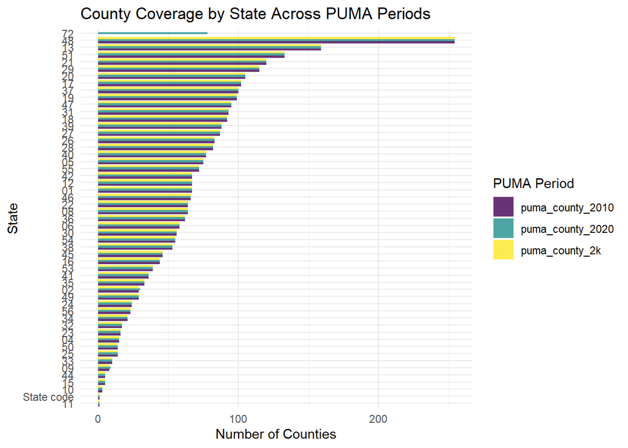

```r
# Coverage visualization
coverage_summary %>%
  pivot_longer(cols = -state, names_to = "cw_period", values_to = "unique_counties") %>%
  ggplot(aes(x = reorder(state, unique_counties), y = unique_counties, fill = cw_period)) +
  geom_col(position = "dodge", alpha = 0.8) +
  coord_flip() +
  scale_fill_viridis_d(name = "PUMA Period") +
  labs(
    title = "County Coverage by State Across PUMA Periods",
    x = "State",
    y = "Number of Counties"
  ) +
  theme_minimal()
```

## Clean crosswalks

Filter out the row containing metadata and select only needed variables.

```r
clean_cw <- function(.x,  .cw_period) {
  .x %>%
  rename_with(tolower) %>%
  filter(!str_detect(state, "State")) %>%
  select(state, starts_with("puma"), -ends_with("name"), county, starts_with("pop"), afact, afact2) %>%
  mutate(crosswalk_period = .cw_period)
}

puma_county_2020 <- clean_cw(puma_county_2020, "2022")
puma_county_2010 <- clean_cw(puma_county_2010, "2012")
puma_county_2k <- clean_cw(puma_county_2k, "2k")
```

Rename GeoCorr variables for working purposes. Add leading zeros to state fips, PUMAs and counties to make them uniform in length.

```r
create_geo_indicators <- function(.x) {
  .x %>%
    rename(
    puma = starts_with("puma"),
    statefip = state
    ) %>%
  mutate(
    statefip = sprintf("%0.2d", as.numeric(statefip)),
    puma = sprintf("%0.5d", as.numeric(puma)),
    county = sprintf("%0.5d", as.numeric(county)),
    across(contains("afact"), ~ as.double(.)),
    across(contains("pop"), ~ as.double(.))
  )
}

puma_county_2020 <- create_geo_indicators(puma_county_2020)
puma_county_2010 <- create_geo_indicators(puma_county_2010)
puma_county_2k <- create_geo_indicators(puma_county_2k)
```

Break out the county FIP code from the county variable which includes the state FIPs code as the first two digits.

```r
puma_county_2020 <- puma_county_2020 %>%
  mutate(county = str_sub(county, start = 3L, end = 5L))

puma_county_2010 <- puma_county_2010 %>%
  mutate(county = str_sub(county, start = 3L, end = 5L))

puma_county_2k <- puma_county_2k %>%
  mutate(county = str_sub(county, start = 3L, end = 5L))
```

## Apply validation to each dataset

```r
validate_crosswalk(puma_county_2020, "2022")
```

```
Validation for 2022 period:
- Rows: 4690
- Unique PUMAs: 1150
- Unique Counties: 3222
- Missing afact values: 0
- Zero afact values: 0
```

```r
validate_crosswalk(puma_county_2010, "2012")
```

```
Validation for 2012 period:
- Rows: 4545
- Unique PUMAs: 982
- Unique Counties: 3142
- Missing afact values: 0
- Zero afact values: 0
```

```r
validate_crosswalk(puma_county_2k, "2k")
```

```
Validation for 2k period:
- Rows: 4432
- Unique PUMAs: 630
- Unique Counties: 3142
- Missing afact values: 0
- Zero afact values: 62
```

Make changes to county definitions so they are consistent between the 2010 and 2020 crosswalks. All changes during the 2010 period are documented on this census [website page] (https://www.census.gov/programs-surveys/geography/technical-documentation/county-changes.2010.html#list-tab-957819518). Only need to address changes in 2014 and beyond.

*New Counties:* - Chugach Census Area, Alaska (02-063): Created from part of former Valdez-Cordova Census Area (02-261) effective January 02, 2019. - Copper River Census Area, Alaska (02-066): Created from part of former Valdez-Cordova Census Area (02-261) effective January 02, 2019.

For this change, use the ratio of afact from 2012 PUMA to 2020 counties to break the county into two.

*Code changes:* - Kusilvak Census Area, Alaska (02-158): Changed name and code from Wade Hampton Census Area (02-270) effective July 1, 2015. - Oglala Lakota County, South Dakota (46-102): Changed name and code from Shannon County (46-113) effective May 1, 2015.

```r
alaska_split <- tibble(
  statefip = c("02", "02"),
  puma = c("00300", "00300"),
  county = c("063", "066"),
  pop10 = c(9636*(0.0435/0.0595), 9636*(0.016/0.0595)),
  afact = c(0.0586*(0.0435/0.0595), 0.0586*(0.016/0.0595)),
  afact2 = c(1, 1)
)

puma_county_2010 <- puma_county_2010 %>%
  mutate(county = ifelse(statefip == "02" & county == "270", "158", county),
         county = ifelse(statefip == "46" & county == "113", "102", county),
         flag = ifelse(statefip == "02" & county == "261", "1", "0")) %>%
  filter(flag != "1") %>%
  bind_rows(alaska_split %>% mutate(crosswalk_period = "2012")) %>%
  select(-flag)

puma_county_2k <- puma_county_2k %>%
  mutate(county = ifelse(statefip == "02" & county == "270", "158", county),
         county = ifelse(statefip == "46" & county == "113", "102", county),
         flag = ifelse(statefip == "02" & county == "261", "1", "0")) %>%
  filter(flag != "1") %>%
  bind_rows(alaska_split %>% mutate(crosswalk_period = "2k")) %>%
  select(-flag)
```

## Create quality variable

Add the necessary components to the crosswalk for producing a data quality flag.

Create flags in the PUMA-county crosswalk for counties where a high percentage of the data comes from outside of the county. Per agreed upon guidance, 75% or more from the county is good, below 35% is bad, in between is marginal. This is calculated by taking the product of percentage of PUMA in the county and percentage of county in the PUMA for each county-PUMA pairing, and summing across the county.

```r
puma_county20 <- puma_county_2020 %>%
  filter(afact > 0) %>%
  mutate(products = afact * afact2)

puma_county10 <- puma_county_2010 %>%
  filter(afact > 0) %>%
  mutate(products = afact * afact2)

puma_county2k <- puma_county_2k %>%
  filter(afact > 0) %>%
  mutate(products = afact * afact2)
```

Calculate the total county population by summing the GeoCorr pop10 and pop20 variables. These pop variables count the population in the PUMA that overlap with the county - note that GeoCorr presents these numbers so that it already accounts for afact (see What is a Correlation List? on the [GeoCorr website](https://mcdc.missouri.edu/applications/docs/geocorr-help.html#weightVar)).

```r
puma_county20 <- puma_county20 %>%
  group_by(statefip, county) %>%
  mutate(sum_products = sum(products),
         county_pop = sum(pop20)) %>%
  ungroup()

puma_county10 <- puma_county10 %>%
  group_by(statefip, county) %>%
  mutate(sum_products = sum(products),
         county_pop = sum(pop10)) %>%
  ungroup()

puma_county2k <- puma_county2k %>%
  group_by(statefip, county) %>%
  mutate(sum_products = sum(products),
         county_pop = sum(pop10)) %>%
  ungroup()
```

```r
puma_county2k %>%
  select(sum_products) %>%
  summary()
```

```
  sum_products
 Min.   :0.0004
 1st Qu.:0.1117
 Median :0.3422
 Mean   :0.5006
 3rd Qu.:0.9999
 Max.   :1.0002
```

```r
puma_county10 %>%
  select(sum_products) %>%
  summary()
```

```
  sum_products
 Min.   :0.0004
 1st Qu.:0.1241
 Median :0.4068
 Mean   :0.5294
 3rd Qu.:1.0000
 Max.   :1.0002
```

```r
puma_county20 %>%
  select(sum_products) %>%
  summary()
```

```
  sum_products
 Min.   :0.0003
 1st Qu.:0.1239
 Median :0.4334
 Mean   :0.5390
 3rd Qu.:1.0000
 Max.   :1.0002
```

Rank sum_product based on the guidance described above (1 to 3, with 1 being best) and create a new variable representing the quality of geographic allocation.

```r
geographic_allocation <- function(.x) {
  .x %>%
    mutate(
    geographic_allocation_quality =
      case_when(
        sum_products >= 0.75 ~ 1,
        sum_products >= 0.35 ~ 2,
        sum_products < 0.35 ~ 3
      )
    )
}

puma_county20 <- geographic_allocation(puma_county20)
puma_county10 <- geographic_allocation(puma_county10)
puma_county2k <- geographic_allocation(puma_county2k)
```

We want to join the crosswalks together so they can be merged onto multi-year census files. Make the variable names universal.

```r
puma_county20 <- puma_county20 %>%
 rename(population = pop20)

puma_county10 <- puma_county10 %>%
  rename(population = pop10)

puma_county2k <- puma_county2k %>%
  rename(population = pop10)
```

## Comparative Data Quality Analysis

Visualize key variables across all three crosswalk periods for comparison.

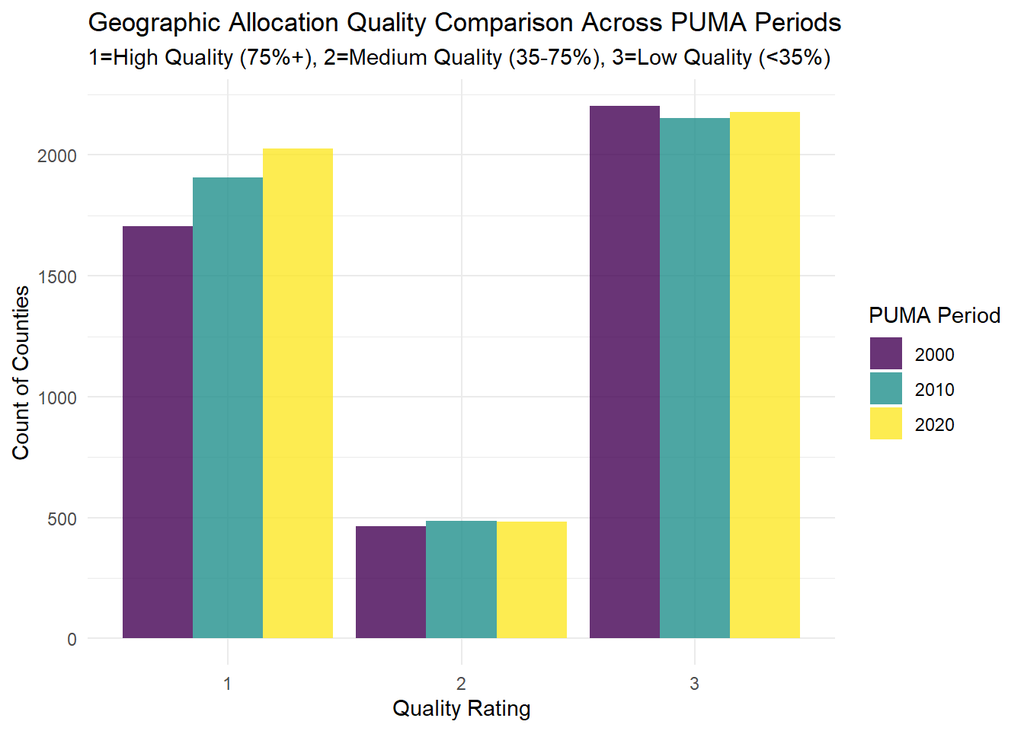

```r
# Create combined quality comparison
quality_comparison <- bind_rows(
  puma_county20 %>% select(crosswalk_period, geographic_allocation_quality) %>% mutate(type = "2020"),
  puma_county10 %>% select(crosswalk_period, geographic_allocation_quality) %>% mutate(type = "2010"),
  puma_county2k %>% select(crosswalk_period, geographic_allocation_quality) %>% mutate(type = "2000")
)

quality_comparison %>%
  ggplot(aes(x = factor(geographic_allocation_quality), fill = type)) +
  geom_bar(position = "dodge", alpha = 0.8) +
  scale_fill_viridis_d(name = "PUMA Period") +
  labs(
    title = "Geographic Allocation Quality Comparison Across PUMA Periods",
    subtitle = "1=High Quality (75%+), 2=Medium Quality (35-75%), 3=Low Quality (<35%)",
    x = "Quality Rating",
    y = "Count of Counties"
  ) +
  theme_minimal()
```

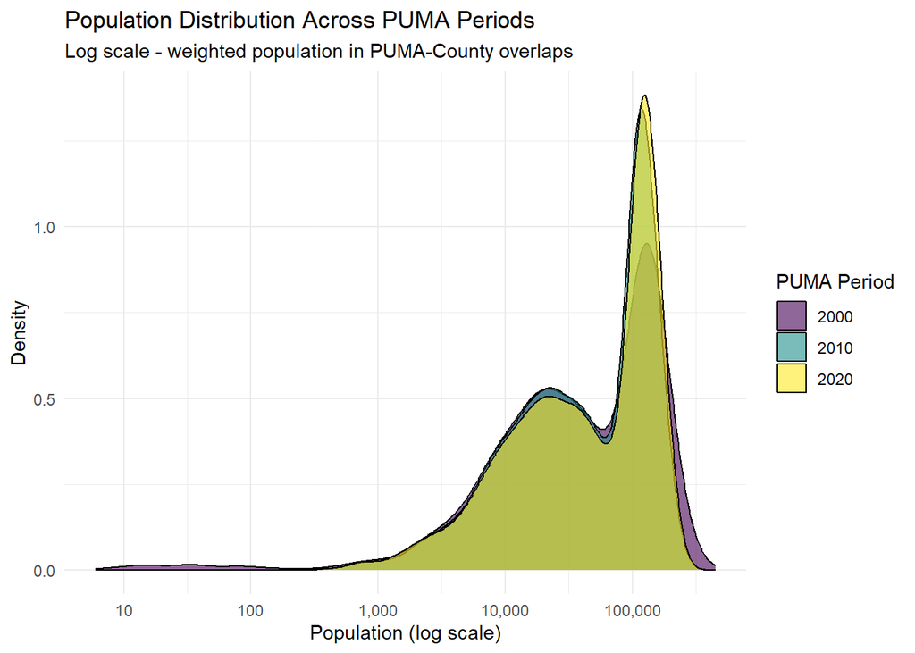

```r
# Combined population distribution
pop_combined <- bind_rows(
  puma_county20 %>% select(population, crosswalk_period) %>% mutate(period = "2020"),
  puma_county10 %>% select(population, crosswalk_period) %>% mutate(period = "2010"),
  puma_county2k %>% select(population, crosswalk_period) %>% mutate(period = "2000")
)

pop_combined %>%
  ggplot(aes(x = population, fill = period)) +
  geom_density(alpha = 0.6) +
  scale_x_log10(labels = scales::comma_format()) +
  scale_fill_viridis_d(name = "PUMA Period") +
  labs(
    title = "Population Distribution Across PUMA Periods",
    subtitle = "Log scale - weighted population in PUMA-County overlaps",
    x = "Population (log scale)",
    y = "Density"
  ) +
  theme_minimal()
```

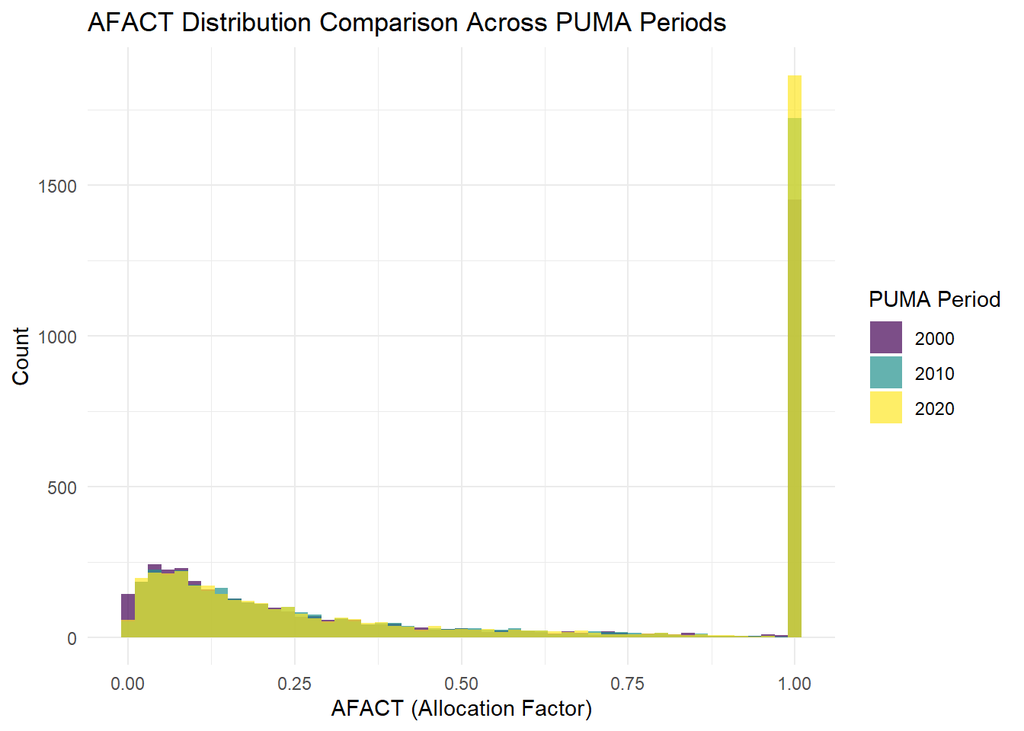

```r
# AFACT distribution comparison
afact_combined <- bind_rows(
  puma_county20 %>% select(afact, crosswalk_period) %>% mutate(period = "2020"),
  puma_county10 %>% select(afact, crosswalk_period) %>% mutate(period = "2010"),
  puma_county2k %>% select(afact, crosswalk_period) %>% mutate(period = "2000")
)

afact_combined %>%
  ggplot(aes(x = afact, fill = period)) +
  geom_histogram(alpha = 0.7, position = "identity", binwidth = 0.02) +
  scale_fill_viridis_d(name = "PUMA Period") +
  labs(
    title = "AFACT Distribution Comparison Across PUMA Periods",
    x = "AFACT (Allocation Factor)",
    y = "Count"
  ) +
  theme_minimal()
```

## Finalize

Finally, bind the crosswalks together and sort by cross-walk period, state, and county. Clean up intermediate objects for memory management.

```r
# Clean up intermediate objects
rm(puma_county_2020, puma_county_2010, puma_county_2k)

# Combine all crosswalks with optimized memory usage
puma_county <- puma_county20 %>%
  bind_rows(puma_county10, puma_county2k) %>%
  arrange(crosswalk_period, statefip, county) %>%
  select(crosswalk_period, statefip, county, puma, afact, afact2,
         population, products, sum_products, geographic_allocation_quality)
```

## Write files

```r
write_csv(puma_county, here::here("geographic-crosswalks", "data", "crosswalk_puma_to_county.csv"))
```